# Exercises: Discrete random variables

2022-09-12

### Introduction to probability

**Exercise 1** The probability of carrying mutations (one or more) in the breast cancer gene BRCA1 is 0.01. What is the probability of not carrying any mutations in BRCA1?

*Solution*

According to the rule of complement $P(no\,mutation) = 1 - P(mutations) = 1 - 0.01 = 0.99$

**Exercise 2** When tossing a fair coin

1. what is the probability of heads?
2. what is the probability of tails?

*Solution*

For a fair coin the probability of heads and tails are equal; $P(H) = P(T)$. According to the rule of complement $p(H) = 1 - P(T)$

It follows that

1. $P(H) = 0.5$
2. $P(T) = 0.5$

**Exercise 3** In a region in Sweden with many children the number of children per household is between 0 and 6. The probability mass function is as follows;

| x | 0 | 1 | 2 | 3 | 4 | 5 | 6 |
| --- | --- | --- | --- | --- | --- | --- | --- |
| p(x) | 0.14 | 0.20 | 0.27 | 0.19 | 0.13 | 0.05 | 0.02 |

In a randomly choosen household

1. what is the probability of exactly 3 children?
2. what is the probability of less than 3 children?
3. what is the probability of 3 or less children?
4. what is the probability of an even number of children?

In your answers, denote the probability with a mathematical expression (such as $P(X>4)$) and calculate its value.

*Solution*

The number of children in a random household is a random variable, $X$.

1. $P(X=3) = 0.19$
2. $P(X<3) = P(X=0) + P(X=1) + P(X=2) = 0.14 + 0.20 + 0.27 = 0.61$
3. $P(X \leq 3) = P(X=3) + P(X<3) = 0.19 + 0.61 = 0.80$
4. $P(even\,X) = P(X=0) + P(X=2) + P(X=4) + P(X=6) = 0.14 + 0.27 + 0.13 + 0.02 = 0.56$

**Exercise 4** When tossing a fair six-sided die

1. what is the probability of getting 6?
2. what is the probability of an even number?
3. what is the probability of getting 3 or more?
4. what is the expected value of dots on the die?

*Solution*

The random variable, $X$, describe the number of dots on the upper face of a die.

1. $P(X=6) = \frac{1}{6}$
2. $P(even\, X) = \frac{3}{6} = \frac{1}{2}$
3. $P(X \geq 3) = \frac{4}{6} = \frac{2}{3}$
4. $E[X] = 1*\frac{1}{6} + 2*\frac{1}{6} + 3*\frac{1}{6} + 4*\frac{1}{6} + 5*\frac{1}{6} + 6*\frac{1}{6} = 3.5$

### Simulation

**Exercise 5** In a single coin toss the probability of heads is 0.5.

In 20 coin tosses,

1. what is the probability of exactly 15 heads?
2. what is the probability of less than 7 heads?
3. What is the most probable number of heads?
4. what is the probability of 5 tails or less?
5. what is the probability of 2 heads or less?

*Solution*

*Answers*

1. 0.015
2. 0.058
3. 10
4. 0.020
5. 0.0002

Simulate as in the lecture;

```r
## A single coin toss
sample(c("H", "T"), size=1)
```

```
## [1] "H"
```

```r
## Another coin toss
sample(c("H", "T"), size=1)
```

```
## [1] "H"
```

```r
## 20 independent coin tosses
(coins <- sample(c("H", "T"), size=20, replace=TRUE))
```

```
##  [1] "T" "T" "H" "T" "T" "H" "H" "H" "T" "T" "T" "T" "H" "H" "T" "H" "T" "T" "H" "H"
```

```r
## How many heads did we get in these particular 20 draws?
sum(coins == "H")
```

```
## [1] 9
```

```r
## The simulation is about repeating this (20 random draws and summing up the number of heads) many times. To do it 10000 times;
Nheads <- replicate(10000, {
  coins <- sample(c("H", "T"), size=20, replace=TRUE)
  sum(coins == "H")
})
```

1. Probability of exactly 15 heads

```r
## Number of times of the 10000 with exactly 15 heads
sum(Nheads==15)
```

```
## [1] 151
```

```r
## divide by 10000 to get the probability
sum(Nheads==15)/10000
```

```
## [1] 0.0151
```

```r
## or compute using mean (why does this work?)
mean(Nheads==15)
```

```
## [1] 0.0151
```

2. Probability of less than 7 heads

```r
mean(Nheads<7)
```

```
## [1] 0.0521
```

3. What is the most probable number of heads?

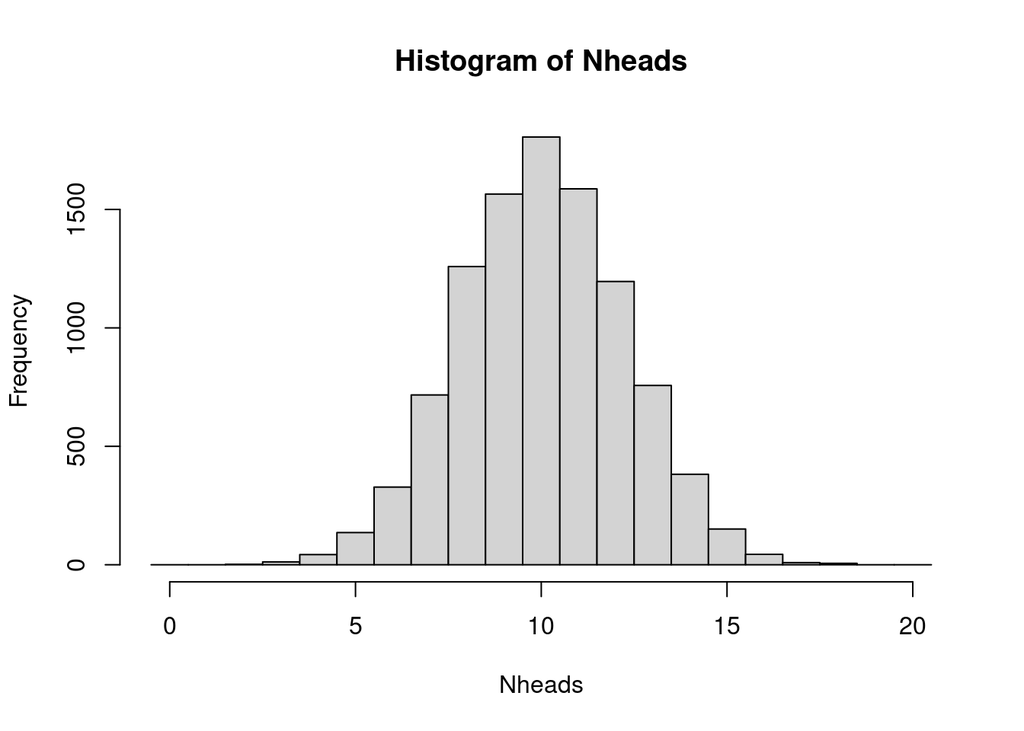

```r
## plot the distribution and read the graph
hist(Nheads, breaks=0:21-0.5)
```

```r
## or tabulate
table(Nheads)
```

```
## Nheads
##    2    3    4    5    6    7    8    9   10   11   12   13   14   15   16   17   18
##    2   12   43  136  328  717 1259 1565 1806 1587 1196  757  382  151   44    9    6
```

4. What is the probability of 5 tails or less?

To get five or less tails out of 20 throws is equal to getting 15 or more heads out of 20.

```r
## probability of 15 heads or more
mean(Nheads>=15)
```

```
## [1] 0.021
```

5. what is the probability of 2 heads or less?

```r
mean(Nheads<=2)
```

```
## [1] 2e-04
```

```r
sum(Nheads<=2)
```

```
## [1] 2
```

```r
## with this low number of observations, more repeats is required to get a more accurate answer

Nheads <- replicate(1000000, {
  coins <- sample(c("H", "T"), size=20, replace=TRUE)
  sum(coins == "H")
})
sum(Nheads<=2)
```

```
## [1] 197
```

```r
mean(Nheads<=2)
```

```
## [1] 0.000197
```

**Exercise 6** In a clinical trial, enrolled patients are randomly assigned to treatment or control group with equal probability.

For a single patient, what is the probability of being assigned to

1. the treatment group?
2. the control group?

If 20 patients are enrolled in the study;

3. what is the probability of exactly 15 in the treatment group?
4. what is the probability of less than 7 in the treatment group?
5. What is the most probable number of patients in the treatment group?
6. what is the probability of 5 or less patients in the control group?
7. what is the probability of 2 or less patients in the treatment group?

*Solution*

This can be solved just as the coin toss exercise.

1. The probability of assigning to control (C) and treatment (T) group are equal and sum up to 1. Hence $P(T) = 0.5$ and;
2. $P(C) = 0.5$

Simulate the assignment of patients into T or C groups.

```r
## Randomization for a single patient
sample(c("T", "C"), size=1)
```

```
## [1] "T"
```

```r
## Randomize 20 independent patients
(patients <- sample(c("T", "c"), size=20, replace=TRUE))
```

```
##  [1] "T" "T" "T" "T" "c" "T" "T" "c" "T" "c" "c" "T" "T" "c" "T" "T" "T" "T" "c" "c"
```

```r
## How many patients are assigned to treatment group?
sum(patients == "T")
```

```
## [1] 13
```

```r
## Simulate by repeating 10000 times
Ntreat <- replicate(10000, {
  patients <- sample(c("T", "C"), size=20, replace=TRUE)
  sum(patients == "T")
})
```

3. Probability of exactly 15 T

```r
## Proportion of the 10000 repeats with exactly 15 T
mean(Ntreat==15)
```

```
## [1] 0.0129
```

4. Probability of less than 7 T

```r
mean(Ntreat<7)
```

```
## [1] 0.0598
```

5. What is the most probable number of T patients?

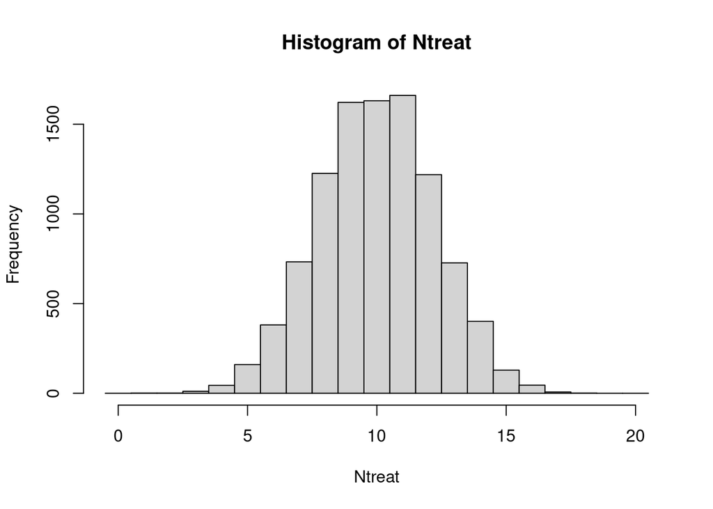

```r
## plot the distribution and read the graph
hist(Ntreat, breaks=0:21-0.5)
```

```r
## or tabulate
table(Ntreat)
```

```
## Ntreat
##    1    2    3    4    5    6    7    8    9   10   11   12   13   14   15   16   17
##    1    1   11   44  160  381  733 1226 1622 1631 1661 1219  727  401  129   45    7
##   18
##    1
```

6. What is the probability of 5 C or less?

To get five or less C out of 20 throws is equal to getting 15 or more T out of 20.

```r
## probability of 15 T or more
mean(Ntreat>=15)
```

```
## [1] 0.0182
```

7. what is the probability of 2 T or less?

```r
mean(Ntreat<=2)
```

```
## [1] 2e-04
```

```r
sum(Ntreat<=2)
```

```
## [1] 2
```

```r
## with this low number of observations, more repeats is required to get a more accurate answer

Ntreat <- replicate(1000000, {
  patients <- sample(c("T", "C"), size=20, replace=TRUE)
  sum(patients == "T")
})
sum(Ntreat<=2)
```

```
## [1] 219
```

```r
mean(Ntreat<=2)
```

```
## [1] 0.000219
```

**Exercise 7** When rolling 10 six-sided dice, study the number of sixes.

1. Define the random variable of interest
2. What are the possible outcomes?
3. Using simulation, estimate the probability mass function
4. what is the probability to get at least 5 sixes?
5. Which is the most likely number of sixes?
6. What is the probability to get exactly 2 sixes?
7. On average how many sixes do you get when throwing ten dice?

**Exercise 8** In a bacterial sample, 1/6 are antibiotic resistant. From bacterial colonies on an agar plate, you randomly pick 10 colonies and investigate how many that are antibiotic resistant.

1. Define the random variable of interest
2. What are the possible outcomes?
3. Using simulation, estimate the probability mass function
4. what is the probability to get at least 5 antibiotic resistant colonies?
5. Which is the most likely number of antibioitic colonies?
6. What is the probability to get exactly 2 antibiotic resistant colonies?
7. On average how many antibiotic resistant colonies would you get if the experiment is repeated many time?

*Solution*

1. $X$, the number of sixes when rolling 10 dice.
2. ${0, 1, 2, 3, 4, 5, 6, 7, 8, 9, 10}$

```r
##Simulate thowing 10 dice and counting the number of sixes.
N <- replicate(100000, sum(sample(1:6, size=10, replace=TRUE)==6))
table(N)
```

```
## N
##     0     1     2     3     4     5     6     7     8
## 15975 32474 29115 15546  5321  1319   232    14     4
```

```r
##The probability mass function
table(N)/length(N)
```

```
## N
##       0       1       2       3       4       5       6       7       8
## 0.15975 0.32474 0.29115 0.15546 0.05321 0.01319 0.00232 0.00014 0.00004
```

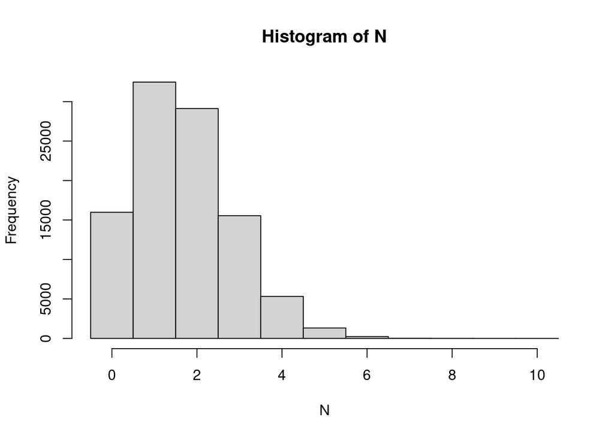

```r
hist(N, breaks=(0:11)-0.5)
```

4. 0.015

```
## [1] 1569
```

```
## [1] 0.01569
```

```
## [1] 0.01569
```

5. 1 (Use the PMF to answer this question)
6. 0.29

```r
mean(N==2)
```

```
## [1] 0.2912
```

7. 1.7

```r
mean(N)
```

```
## [1] 1.667
```

```r
10*1/6
```

```
## [1] 1.667
```

**Exercise 9** A deck of cards consists of 52 cards; 13 diamonds, 13 spades, 13 hearts and 13 clubs. When five cards are randomly selected (a poker hand), what is the probability of getting all hearts?

*Solution*

*Answer:* 0.00049

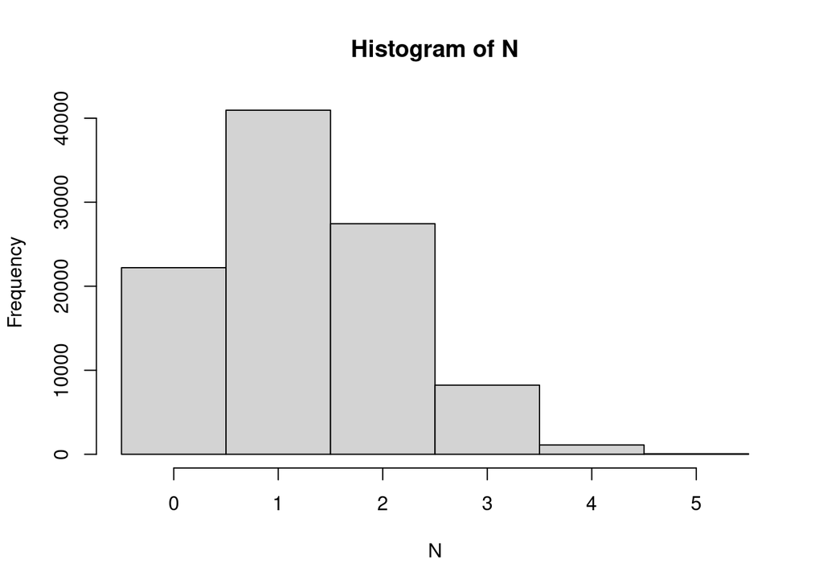

```r
N <- replicate(100000, sum(sample(rep(0:1, c(39,13)), size=5)))
hist(N, breaks=(0:6)-.5)
```

```r
## P(N==5)
mean(N==5)
```

```
## [1] 0.00058
```

**Exercise 10** 30% of a large population is allergic to pollen. If you randomly select 3 people to participate in your study, what is the probability than none of them will be allergic to pollen?

*Solution*

```r
## Solution using 100 replicates
x <- replicate(100, sum(sample(c(0,0,0,0,0,0,0,1,1,1), size=3, replace=TRUE)))
table(x)
```

```
## x
##  0  1  2  3
## 33 46 18  3
```

```r
mean(x==0)
```

```
## [1] 0.33
```

```r
## Solution using 1000 replicates
x <- replicate(1000, sum(sample(c(0,0,0,0,0,0,0,1,1,1), size=3, replace=TRUE)))
table(x)
```

```
## x
##   0   1   2   3
## 327 449 196  28
```

```r
mean(x==0)
```

```
## [1] 0.327
```

```r
## Solution using 100000 replicates
x <- replicate(100000, sum(sample(c(0,0,0,0,0,0,0,1,1,1), size=3, replace=TRUE)))
table(x)
```

```
## x
##     0     1     2     3
## 34320 43895 18978  2807
```

```r
mean(x==0)
```

```
## [1] 0.3432
```

**Exercise 11** In a class of 20 students, 6 are allergic to pollen. If you randomly select 3 of the students to participate in your study, what is the probability than none of them will be allergic to pollen?

*Solution*

```r
## Solution using 100000 replicates
x <- replicate(100000, sum(sample(rep(c(0, 1), c(14, 6)), size=3, replace=FALSE)))
table(x)
```

```
## x
##     0     1     2     3
## 31828 48130 18254  1788
```

```r
mean(x==0)
```

```
## [1] 0.3183
```

**Exercise 12** Of the 200 persons working at a company, 60 are allergic to pollen. If you randomly select 3 people to participate in your study, what is the probability that none of them are allergic to pollen?

*Solution*

```r
## Solution using 100000 replicates
x <- replicate(100000, sum(sample(rep(c(0, 1), c(140, 60)), size=3, replace=FALSE)))
table(x)
```

```
## x
##     0     1     2     3
## 34148 44453 18778  2621
```

```r
mean(x==0)
```

```
## [1] 0.3415
```

**Exercise 13** Compare your results in 10, 11 and 12. Did you get the same results? Why/why not?

*Solution*

The results differ. In 10 the probability of selecting an allergic person is constant, regardless of the status of previously selected persons. On the other hand in the situations in 11 and 12, the probability of selecting an allergic person changes depending on the persons selected before.

### Parametric discrete distribution

**Exercise 14** Do exercises 10, 11 and 12 again, but using parametric distributions. Compare your results.

*Solution*

```r
## 1.6 Solution using the Binomial distribution
pbinom(0, 3, 0.3)
```

```
## [1] 0.343
```

```r
## 1.7 Solution using the hypergeometric distribution
phyper(0, 6, 20-6, 3)
```

```
## [1] 0.3193
```

```r
## 1.8 Solution using the hypergeometric distribution
phyper(0, 60, 200-60, 3)
```

```
## [1] 0.3408
```

**Exercise 15** **Gene set enrichment analysis**

You have analyzed 20000 genes and a bioinformatician you are collaborating with has sent you a list of 1000 genes that she says are important. You are interested in a particular pathway A. 200 genes in pathway A are represented among the 20000 genes, 20 of these are in the bioinformaticians important list.

If the bioinformatician selected the 1000 genes at random, what is the probability to see 20 or more genes from pathway A in this list?

*Solution*

```r
phyper(20, 200, 20000-200, 1000, lower.tail=FALSE)
```

```
## [1] 0.00109
```

**Exercise 16** **Chance of meeting boss**

Your boss comes in to the office three days per week. You do also come in to work three days per week. If you both choose which days to come in to work at random, what is the probability that a particular week you are in the office at the same time 0, 1, 2 or 3 days, respectively?

*Solution*

```
## x
##     1     2     3
## 29686 60298 10016
```

```
## [1] 0.0 0.3 0.9 1.0
```

### Conditional probability

**Exercise 17** **Diagnostic tests**

A study of a method for cancer prediction is evaluated. Based on the results in the below table estimate;

|  | pos | neg | tot |
| --- | --- | --- | --- |
| not cancer | 98 | 882 | 980 |
| cancer | 16 | 4 | 20 |
| total | 114 | 886 | 1000 |

1. the probability of a positive test result from a person with cancer?
2. the probability of a negative test result from a person without cancer?
3. the probability of having cancer, if the test is positive?
4. the probability of not having cancer, if the test is negative?
5. Connect the four computed probabilities with the following four terms;
- Sensitivity
- Specificity
- Positive predictive value (PPV)
- Negative predictive value (NPV)

*Solution*

1. $P(pos|cancer) = 16/20$, sensitivity
2. $P(neg|not cancer) = 882/980$, specificity
3. $P(cancer|pos) = 16/114$, PPV
4. $P(not cancer|neg) = 882/886$, NPV